# Chintan PDAD Consultation

Keenan Anderson-Fears

6/1/2022

### Formatting

```r
ca <- read_excel("/Users/keenananderson-fears/Desktop/Dr._Liu_Lab/Consultations/Gandhi/Consultation2/PDAD_Case.xlsx")
con <- read_excel("/Users/keenananderson-fears/Desktop/Dr._Liu_Lab/Consultations/Gandhi/Consultation2/PDAD_Control.xlsx")

ca <- ca %>% drop_na(`JF Number`)
con <- con %>% drop_na(`JF Number`)

phenotype1 <- data.frame("Phenotype"=matrix(2, nrow=nrow(ca), ncol=1))
phenotype2 <- data.frame("Phenotype"=matrix(1, nrow=nrow(con), ncol=1))

Ca <- cbind(ca, phenotype1)
Con <- cbind(con, phenotype2)

Full_Data <- rbind(Ca, Con)
Full_Data$Gender <- ifelse(Full_Data$Gender=="Male",1,2)
Full_Data$`Bacterial Cx Pos` <- ifelse(Full_Data$`Bacterial Cx Pos`=="No",0,1)
Full_Data <- Full_Data %>% drop_na(`Bacterial Cx Pos`)
Full_Data[is.na(Full_Data)] <- "00"

Full_Data$Ethnicity <- ifelse(Full_Data$Race == "White" & Full_Data$`Ethnic Category` == "Not Hispanic or Latino", "White",
                         ifelse(Full_Data$Race == "White" & Full_Data$`Ethnic Category` == "Hispanic or Latino", "Latino",
                                ifelse(Full_Data$Race == "Black, not of White origin", "Black",
                                       ifelse(Full_Data$Race == "Asian or Pacific Islander", "Asian", "Mixed"))))
Full_Data <- dummy_cols(Full_Data, select_columns = 'Ethnicity')

write.table(Full_Data,
            "/Users/keenananderson-fears/Desktop/Dr._Liu_Lab/Consultations/Gandhi/Consultation2/Full_Data.txt",
            sep="\t",
            quote=T)

head(Full_Data)
```

```
##   JF Number Age In months Gender  Race        Ethnic Category Weight
## 1     17001             2      1 White Not Hispanic or Latino      5
## 2     17006            16      2 White Not Hispanic or Latino     10
## 3     17009             3      2 White Not Hispanic or Latino      4
## 4     17012             4      2 White     Hispanic or Latino      8
## 5     17013             2      1 White     Hispanic or Latino      6
## 6     17019           1.5      2 White     Hispanic or Latino      5
##   Duration of ventilation (days) Bacterial Cx Pos rs1059046 rs17886395
## 1                              4                1        AC         GG
## 2                              8                1        AC         GG
## 3                              2                1        AC         CG
## 4                             12                1        AA         GG
## 5                              4                1        CC         CG
## 6                             13                0        AC         CG
##   rs1965707 rs1965708 rs1059047 rs1136450 rs1136451 rs1059057 rs4253527
```

[output cut: 27 more lines]

### Obtain CHROM & POS using BiomaRt

```r
mart = useMart("ENSEMBL_MART_SNP", dataset="hsapiens_snp")
snp_ids = colnames(Full_Data)[9:22]
snp_attributes = c("refsnp_id", "chr_name", "chrom_start")
snp_locations = getBM(attributes=snp_attributes,
                      filters="snp_filter",
                      values=snp_ids,
                      mart=mart)
snp_locations
```

```
##     refsnp_id chr_name chrom_start
## 1   rs1059046       10    79559458
## 2   rs1059047       10    79611881
## 3   rs1059057       10    79613765
## 4      rs1124        8    22164004
## 5   rs1130866        2    85666618
## 6   rs1136450       10    79611973
## 7   rs1136451       10    79612325
## 8  rs17886395       10    79558907
## 9   rs1965707       10    79557536
## 10  rs1965708       10    79557289
## 11  rs2243639       10    79941966
## 12  rs4253527       10    79614021
## 13     rs4715        8    22163524
## 14   rs721917       10    79946568
```

### Create Required Files for PLINK(2)

```r
PEDFile <- data.frame(cbind("FID"=paste0("FAM", sample(seq(1, nrow(Full_Data), by=1), replace=F)),
                 "IID"= 1,
                 "PID"=1,
                 "MID"=1,
                 "SEX"=Full_Data$Gender,
                 "Pheno"=Full_Data$Phenotype,
                 "rs1059046"=unlist(lapply(strsplit(Full_Data$rs1059046,''), paste, collapse = ' ')),
                 "rs17886395"=unlist(lapply(strsplit(Full_Data$rs17886395,''), paste, collapse = ' ')),
                 "rs1965707"=unlist(lapply(strsplit(Full_Data$rs1965707,''), paste, collapse = ' ')),
                 "rs1965708"=unlist(lapply(strsplit(Full_Data$rs1965708,''), paste, collapse = ' ')),
                 "rs1059047"=unlist(lapply(strsplit(Full_Data$rs1059047,''), paste, collapse = ' ')),
                 "rs1136450"=unlist(lapply(strsplit(Full_Data$rs1136450,''), paste, collapse = ' ')),
                 "rs1136451"=unlist(lapply(strsplit(Full_Data$rs1136451,''), paste, collapse = ' ')),
                 "rs1059057"=unlist(lapply(strsplit(Full_Data$rs1059057,''), paste, collapse = ' ')),
                 "rs4253527"=unlist(lapply(strsplit(Full_Data$rs4253527,''), paste, collapse = ' ')),
                 "rs1130866"=unlist(lapply(strsplit(Full_Data$rs1130866,''), paste, collapse = ' ')),
                 "rs4715"=unlist(lapply(strsplit(Full_Data$rs4715,''), paste, collapse = ' ')),
                 "rs1124"=unlist(lapply(strsplit(Full_Data$rs1124,''), paste, collapse = ' ')),
                 "rs721917"=unlist(lapply(strsplit(Full_Data$rs721917,''), paste, collapse = ' ')),
                 "rs2243639"=unlist(lapply(strsplit(Full_Data$rs2243639,''), paste, collapse = ' '))))

MAPFile <- data.frame(cbind("chromosome"=snp_locations$chr_name,
                 "rsID"=data.frame("rsID"=snp_locations$refsnp_id),
                 "Genetic Distance"=data.frame("Genetic Distance"=matrix(0, nrow=length(colnames(Full_Data)[9:22]), ncol=1)),
                 "BP"=snp_locations$chrom_start))

CovarFile <- data.frame(cbind("FID"=PEDFile$FID,
                              "IID"=PEDFile$IID,
                              "Sex" = Full_Data$Gender,
                              "Age" = as.numeric(Full_Data$`Age In months`),
                              "Weight" = as.numeric(Full_Data$Weight),
                              "Ventilation" = as.numeric(Full_Data$`Duration of ventilation (days)`),
                              "Infection" = Full_Data$`Bacterial Cx Pos`,
                              "Asian" = Full_Data$Ethnicity_Asian,
                              "Black" = Full_Data$Ethnicity_Black,
                              "Latino" = Full_Data$Ethnicity_Latino,
                              "Mixed" = Full_Data$Ethnicity_Mixed,
                              "White" = Full_Data$Ethnicity_White))

write.table(PEDFile,
            "/Users/keenananderson-fears/Desktop/Dr._Liu_Lab/Consultations/Gandhi/Consultation2/RSVData.ped",
            sep="\t",
            quote=F,
            col.names=F,
            row.names=F)
write.table(MAPFile,
            "/Users/keenananderson-fears/Desktop/Dr._Liu_Lab/Consultations/Gandhi/Consultation2/RSVData.map",
            sep="\t",
            quote=F,
            col.names=F,
            row.names=F)
write.table(CovarFile,
            "/Users/keenananderson-fears/Desktop/Dr._Liu_Lab/Consultations/Gandhi/Consultation2/RSVCovariates.txt",
            sep="\t",
            quote=F,
            col.names=T,
            row.names=F)
```

### Run PLINK(2)

```
plink --file RSVData --out RSVData --make-bed

plink2 --bfile RSVData --covar RSVCovariates.txt --glm hide-covar --covar-variance-standardize --covar-col-nums 3-11
```

### PLINK Results

```r
results <- fread("/Users/keenananderson-fears/Desktop/Dr._Liu_Lab/Consultations/Gandhi/Consultation2/plink2.PHENO1.glm.logistic",
                 sep="\t", header=T)

print(results[,c(3,9,10,12)], max=14)
```

```
##             ID       OR LOG(OR)_SE        P
##  1:  rs1130866 1.057260   0.433709 0.897846
##  2:     rs4715 1.217960   0.232179 0.395739
##  3:     rs1124 1.128590   0.279978 0.665689
##  4:  rs1965708 0.863965   0.228662 0.522514
##  5:  rs1965707 0.575866   0.398554 0.166142
##  6: rs17886395 0.986835   0.432768 0.975570
##  7:  rs1059046 1.159630   0.213837 0.488566
##  8:  rs1059047 0.896234   0.293916 0.709343
##  9:  rs1136450 1.149200   0.220652 0.528533
## 10:  rs1136451 0.750416   0.293445 0.327842
## 11:  rs1059057 1.017970   0.242359 0.941407
## 12:  rs4253527 1.150160   0.240773 0.561210
## 13:  rs2243639 1.184350   0.252427 0.502694
## 14:   rs721917 0.877494   0.240701 0.587173
```

Results were underwhelming to individual level tests, however this holds with the results from previousl analyses.

### Plots for PLINK(2) Results

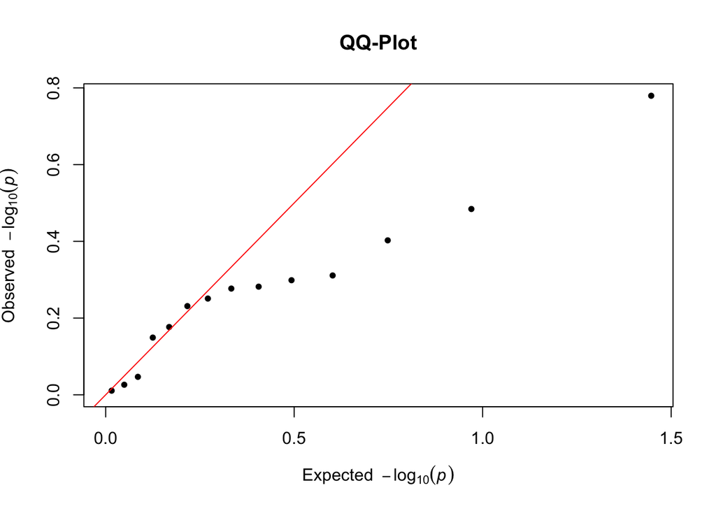

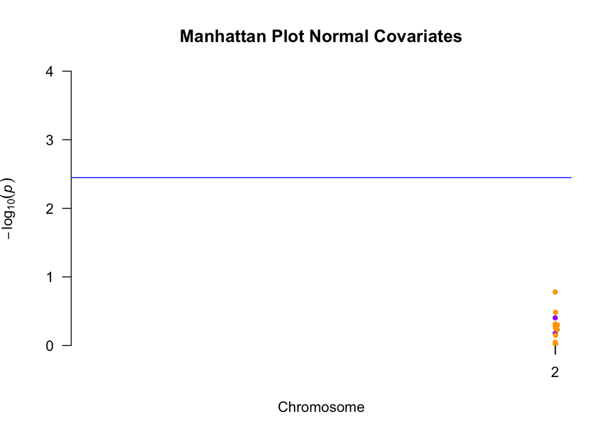

### Formatting for Combined LR Model

```r
recraw <- fread("/Users/keenananderson-fears/Desktop/Dr._Liu_Lab/Consultations/Gandhi/Consultation2/RSVrecode.raw", sep=" ", header=T)
reccov <- fread("/Users/keenananderson-fears/Desktop/Dr._Liu_Lab/Consultations/Gandhi/Consultation2/RSVrecode.cov", sep=" ", header=T)
recraw$PHENOTYPE <- ifelse(recraw$PHENOTYPE == 2, 1, 0)

recraw <- recraw[,-c(1,2,3,4,5)]
reccov <- reccov[,-c(1,2,12)]
recoded <- cbind(recraw,reccov)
```

### Using Factors instead of PLINK’s Recode for SNP Regression

```r
genotypes <- Full_Data[,9:22]
genotypes$rs1059046 <- factor(genotypes$rs1059046, levels = c("CC", "AA", "AC"))
genotypes$rs17886395 <- factor(genotypes$rs17886395, levels = c("GG", "CC", "CG"))
genotypes$rs1965707 <- factor(genotypes$rs1965707, levels = c("TT", "CC", "CT"))
genotypes$rs1965708 <- factor(genotypes$rs1965708, levels = c("AA", "CC", "AC"))
genotypes$rs1059047 <- factor(genotypes$rs1059047, levels = c("TT", "CC", "CT"))
genotypes$rs1136450 <- factor(genotypes$rs1136450, levels = c("CC", "GG", "CG"))
genotypes$rs1136451 <- factor(genotypes$rs1136451, levels = c("AA", "GG", "AG"))
genotypes$rs1059057 <- factor(genotypes$rs1059057, levels = c("AA", "GG", "AG"))
genotypes$rs4253527 <- factor(genotypes$rs4253527, levels = c("CC","TT","CT"))
genotypes$rs1130866 <- factor(genotypes$rs1130866, levels = c("CC","TT","CT"))
genotypes$rs4715 <- factor(genotypes$rs4715, levels = c("CC", "AA", "AC"))
genotypes$rs1124 <- factor(genotypes$rs1124, levels = c("GG", "AA", "AG"))
genotypes$rs721917 <- factor(genotypes$rs721917, levels = c("CC","TT","CT"))
genotypes$rs2243639 <- factor(genotypes$rs2243639, levels = c("GG","AA","AG"))
genotypes <- cbind("Phenotype"=recoded$PHENOTYPE,
                   genotypes,
                   "Sex"=recoded$Sex,
                   "Age"=recoded$Age,
                   "Weight"=recoded$Weight,
                   "Ventilation"=recoded$Ventilation,
                   "Infection"=recoded$Infection,
                   "Asian"=recoded$Asian,
                   "Black"=recoded$Black,
                   "Latino"=recoded$Latino,
                   "Mixed"=recoded$Mixed)
```

### SNP Regression Results

```r
mod1 <- glm(Phenotype ~ ., data=genotypes, family=binomial)
summary(mod1)
```

```
##
## Call:
## glm(formula = Phenotype ~ ., family = binomial, data = genotypes)
##
## Deviance Residuals:
##     Min       1Q   Median       3Q      Max
## -1.8411  -0.6987  -0.3347   0.7256   2.8824
##
## Coefficients: (1 not defined because of singularities)
##                Estimate Std. Error z value Pr(>|z|)
## (Intercept)    -2.30837    1.63554  -1.411   0.1581
## rs1059046AA    -0.33415    1.41710  -0.236   0.8136
## rs1059046AC    -0.41568    1.10936  -0.375   0.7079
## rs17886395CC  -21.27262 2024.41689  -0.011   0.9916
## rs17886395CG   -0.88421    0.94725  -0.933   0.3506
## rs1965707CC    -3.92554    2.15470  -1.822   0.0685 .
## rs1965707CT    -1.06695    1.47140  -0.725   0.4684
## rs1965708CC     4.16139    2.51905   1.652   0.0985 .
## rs1965708AC     1.39118    1.84584   0.754   0.4510
## rs1059047CC   -51.63718 8846.28877  -0.006   0.9953
## rs1059047CT     1.49308    1.58193   0.944   0.3453
## rs1136450GG    -0.58590    1.29729  -0.452   0.6515
## rs1136450CG     0.52822    1.05357   0.501   0.6161
## rs1136451GG    54.62199 8167.23418   0.007   0.9947
## rs1136451AG    16.96943 3956.18046   0.004   0.9966
## rs1059057GG          NA         NA      NA       NA
## rs1059057AG   -18.37024 3956.18095  -0.005   0.9963
## rs4253527TT   -72.87645 8513.22868  -0.009   0.9932
## rs4253527CT   -19.33091 3956.18051  -0.005   0.9961
## rs1130866TT    -0.10474    0.64550  -0.162   0.8711
## rs1130866CT    -1.01352    0.63014  -1.608   0.1077
## rs4715AA       -1.36165    1.43125  -0.951   0.3414
## rs4715AC        0.54351    0.73239   0.742   0.4580
## rs1124AA        1.27572    1.24582   1.024   0.3058
## rs1124AG       -0.73997    0.68946  -1.073   0.2832
## rs721917TT     -0.58828    0.79531  -0.740   0.4595
## rs721917CT     -1.79358    0.70348  -2.550   0.0108 *
## rs2243639AA     0.03103    0.83436   0.037   0.9703
## rs2243639AG     0.01476    0.56424   0.026   0.9791
## Sex             0.49824    0.49574   1.005   0.3149
## Age            -0.01168    0.10083  -0.116   0.9078
## Weight          0.25640    0.17985   1.426   0.1540
## Ventilation     0.08974    0.05160   1.739   0.0820 .
## Infection       0.77191    0.56384   1.369   0.1710
## Asian         -16.04013 1712.84441  -0.009   0.9925
## Black           1.19586    0.70004   1.708   0.0876 .
## Latino          0.64323    0.58561   1.098   0.2720
## Mixed          -0.19294    1.23206  -0.157   0.8756
## ---
## Signif. codes:  0 '***' 0.001 '**' 0.01 '*' 0.05 '.' 0.1 ' ' 1
##
## (Dispersion parameter for binomial family taken to be 1)
##
##     Null deviance: 224.51  on 175  degrees of freedom
## Residual deviance: 156.64  on 139  degrees of freedom
##   (19 observations deleted due to missingness)
## AIC: 230.64
##
## Number of Fisher Scoring iterations: 16
```

Odds Ratios & CIs of Significant SNPs & Covariates Before Correction

| Variant | OR | P | 2.5% | 97.5% |
| --- | --- | --- | --- | --- |
| rs1965707CC | 0.019731543638731 | 0.0684774722122787 | 0.000289121609494606 | 1.34660918306216 |
| rs1965708CC | 64.1603862440798 | 0.098541270238848 | 0.460308018183803 | 8943.04465786158 |
| rs721917CT | 0.166363859856643 | 0.0107849758760388 | 0.041904262327533 | 0.660480159513889 |
| Ventilation | 1.09389384230213 | 0.0820087791325688 | 0.988670092019057 | 1.21031651294601 |
| Black | 3.30640596801791 | 0.0875861684939661 | 0.838453514144832 | 13.038672080103 |

The combined SNP model identified 0 significant variants after Bonferroni correction.

### SNP Likelihood Ratio Tests

Finally we assess the goodness of fit between a model with clinical covariates only and a model containing clinical covariates and our genetic variants

```r
genotypes <- na.omit(genotypes)
fullmodel <- glm(Phenotype ~ ., data=genotypes, family=binomial)
covmodel <- glm(Phenotype ~ Sex + Age + Weight + Ventilation + Infection + Black + Asian + Latino + Mixed, data=genotypes, family=binomial)

lrtest(fullmodel, covmodel)
```

```
## Likelihood ratio test for MLE method
## Chi-squared 27 d.f. =  39.61188 , P value =  0.05567906
```

Here we ask does the data fit each of the two models equally well, and from this we see that with a Chisq of 39.612 and P-Value of 0.05568, that we accept the null hypothesis that the two are equal. Therefore, the model with the additional genetic variants is not a better fit and offers no significant improvement over the model with only the covarites as our predictors.

### Generating Frequency Tables for Cases and Controls

```r
Ca$Gender <- ifelse(Ca$Gender=="Male",1,2)
Ca$`Bacterial Cx Pos` <- ifelse(Ca$`Bacterial Cx Pos`=="No",0,1)
Ca <- Ca %>% drop_na(`Bacterial Cx Pos`)
Ca[is.na(Ca)] <- "00"

Ca$Ethnicity <- ifelse(Ca$Race == "White" & Ca$`Ethnic Category` == "Not Hispanic or Latino", "White",
                         ifelse(Ca$Race == "White" & Ca$`Ethnic Category` == "Hispanic or Latino", "Latino",
                                ifelse(Ca$Race == "Black, not of White origin", "Black",
                                       ifelse(Ca$Race == "Asian or Pacific Islander", "Asian", "Mixed"))))
Ca <- dummy_cols(Ca, select_columns = 'Ethnicity')

Camart = useMart("ENSEMBL_MART_SNP", dataset="hsapiens_snp")
Casnp_ids = colnames(Ca)[9:22]
Casnp_attributes = c("refsnp_id", "chr_name", "chrom_start")
Casnp_locations = getBM(attributes=Casnp_attributes,
                      filters="snp_filter",
                      values=Casnp_ids,
                      mart=Camart)
Casnp_locations
```

```
##     refsnp_id chr_name chrom_start
## 1   rs1059046       10    79559458
## 2   rs1059047       10    79611881
## 3   rs1059057       10    79613765
## 4      rs1124        8    22164004
## 5   rs1130866        2    85666618
## 6   rs1136450       10    79611973
## 7   rs1136451       10    79612325
## 8  rs17886395       10    79558907
## 9   rs1965707       10    79557536
## 10  rs1965708       10    79557289
## 11  rs2243639       10    79941966
## 12  rs4253527       10    79614021
## 13     rs4715        8    22163524
## 14   rs721917       10    79946568
```

```r
Con$Gender <- ifelse(Con$Gender=="Male",1,2)
Con$`Bacterial Cx Pos` <- ifelse(Con$`Bacterial Cx Pos`=="No",0,1)
Con <- Con %>% drop_na(`Bacterial Cx Pos`)
Con[is.na(Con)] <- "00"

Con$Ethnicity <- ifelse(Con$Race == "White" & Con$`Ethnic Category` == "Not Hispanic or Latino", "White",
                         ifelse(Con$Race == "White" & Con$`Ethnic Category` == "Hispanic or Latino", "Latino",
                                ifelse(Con$Race == "Black, not of White origin", "Black",
                                       ifelse(Con$Race == "Asian or Pacific Islander", "Asian", "Mixed"))))
Con <- dummy_cols(Con, select_columns = 'Ethnicity')

Conmart = useMart("ENSEMBL_MART_SNP", dataset="hsapiens_snp")
Consnp_ids = colnames(Con)[9:22]
Consnp_attributes = c("refsnp_id", "chr_name", "chrom_start")
Consnp_locations = getBM(attributes=Consnp_attributes,
                      filters="snp_filter",
                      values=Consnp_ids,
                      mart=Conmart)
Consnp_locations
```

```
##     refsnp_id chr_name chrom_start
## 1   rs1059046       10    79559458
## 2   rs1059047       10    79611881
## 3   rs1059057       10    79613765
## 4      rs1124        8    22164004
## 5   rs1130866        2    85666618
## 6   rs1136450       10    79611973
## 7   rs1136451       10    79612325
## 8  rs17886395       10    79558907
## 9   rs1965707       10    79557536
## 10  rs1965708       10    79557289
## 11  rs2243639       10    79941966
## 12  rs4253527       10    79614021
## 13     rs4715        8    22163524
## 14   rs721917       10    79946568
```

```r
### Cases ###
PEDFile <- data.frame(cbind("FID"=paste0("FAM", sample(seq(1, nrow(Ca), by=1), replace=F)),
                 "IID"= 1,
                 "PID"=1,
                 "MID"=1,
                 "SEX"=Ca$Gender,
                 "Pheno"=Ca$Phenotype,
                 "rs1059046"=unlist(lapply(strsplit(Ca$rs1059046,''), paste, collapse = ' ')),
                 "rs17886395"=unlist(lapply(strsplit(Ca$rs17886395,''), paste, collapse = ' ')),
                 "rs1965707"=unlist(lapply(strsplit(Ca$rs1965707,''), paste, collapse = ' ')),
                 "rs1965708"=unlist(lapply(strsplit(Ca$rs1965708,''), paste, collapse = ' ')),
                 "rs1059047"=unlist(lapply(strsplit(Ca$rs1059047,''), paste, collapse = ' ')),
                 "rs1136450"=unlist(lapply(strsplit(Ca$rs1136450,''), paste, collapse = ' ')),
                 "rs1136451"=unlist(lapply(strsplit(Ca$rs1136451,''), paste, collapse = ' ')),
                 "rs1059057"=unlist(lapply(strsplit(Ca$rs1059057,''), paste, collapse = ' ')),
                 "rs4253527"=unlist(lapply(strsplit(Ca$rs4253527,''), paste, collapse = ' ')),
                 "rs1130866"=unlist(lapply(strsplit(Ca$rs1130866,''), paste, collapse = ' ')),
                 "rs4715"=unlist(lapply(strsplit(Ca$rs4715,''), paste, collapse = ' ')),
                 "rs1124"=unlist(lapply(strsplit(Ca$rs1124,''), paste, collapse = ' ')),
                 "rs721917"=unlist(lapply(strsplit(Ca$rs721917,''), paste, collapse = ' ')),
                 "rs2243639"=unlist(lapply(strsplit(Ca$rs2243639,''), paste, collapse = ' '))))

MAPFile <- data.frame(cbind("chromosome"=Casnp_locations$chr_name,
                 "rsID"=data.frame("rsID"=Casnp_locations$refsnp_id),
                 "Genetic Distance"=data.frame("Genetic Distance"=matrix(0, nrow=length(colnames(Ca)[9:22]), ncol=1)),
                 "BP"=Casnp_locations$chrom_start))

CovarFile <- data.frame(cbind("FID"=PEDFile$FID,
                              "IID"=PEDFile$IID,
                              "Sex" = Ca$Gender,
                              "Age" = as.numeric(Ca$`Age In months`),
                              "Weight" = as.numeric(Ca$Weight),
                              "Ventilation" = as.numeric(Ca$`Duration of ventilation (days)`),
                              "Infection" = Ca$`Bacterial Cx Pos`,
                              "Asian" = Ca$Ethnicity_Asian,
                              "Black" = Ca$Ethnicity_Black,
                              "Latino" = Ca$Ethnicity_Latino,
                              "Mixed" = Ca$Ethnicity_Mixed,
                              "White" = Ca$Ethnicity_White))

write.table(PEDFile,
            "/Users/keenananderson-fears/Desktop/Dr._Liu_Lab/Consultations/Gandhi/Consultation2/PDAD_Cases.ped",
            sep="\t",
            quote=F,
            col.names=F,
            row.names=F)
write.table(MAPFile,
            "/Users/keenananderson-fears/Desktop/Dr._Liu_Lab/Consultations/Gandhi/Consultation2/PDAD_Cases.map",
            sep="\t",
            quote=F,
            col.names=F,
            row.names=F)
write.table(CovarFile,
            "/Users/keenananderson-fears/Desktop/Dr._Liu_Lab/Consultations/Gandhi/Consultation2/PDAD_Cases.txt",
            sep="\t",
            quote=F,
            col.names=T,
            row.names=F)

### Controls ###
PEDFile <- data.frame(cbind("FID"=paste0("FAM", sample(seq(1, nrow(Con), by=1), replace=F)),
                 "IID"= 1,
                 "PID"=1,
                 "MID"=1,
                 "SEX"=Con$Gender,
                 "Pheno"=Con$Phenotype,
                 "rs1059046"=unlist(lapply(strsplit(Con$rs1059046,''), paste, collapse = ' ')),
                 "rs17886395"=unlist(lapply(strsplit(Con$rs17886395,''), paste, collapse = ' ')),
                 "rs1965707"=unlist(lapply(strsplit(Con$rs1965707,''), paste, collapse = ' ')),
                 "rs1965708"=unlist(lapply(strsplit(Con$rs1965708,''), paste, collapse = ' ')),
                 "rs1059047"=unlist(lapply(strsplit(Con$rs1059047,''), paste, collapse = ' ')),
                 "rs1136450"=unlist(lapply(strsplit(Con$rs1136450,''), paste, collapse = ' ')),
                 "rs1136451"=unlist(lapply(strsplit(Con$rs1136451,''), paste, collapse = ' ')),
                 "rs1059057"=unlist(lapply(strsplit(Con$rs1059057,''), paste, collapse = ' ')),
                 "rs4253527"=unlist(lapply(strsplit(Con$rs4253527,''), paste, collapse = ' ')),
                 "rs1130866"=unlist(lapply(strsplit(Con$rs1130866,''), paste, collapse = ' ')),
                 "rs4715"=unlist(lapply(strsplit(Con$rs4715,''), paste, collapse = ' ')),
                 "rs1124"=unlist(lapply(strsplit(Con$rs1124,''), paste, collapse = ' ')),
                 "rs721917"=unlist(lapply(strsplit(Con$rs721917,''), paste, collapse = ' ')),
                 "rs2243639"=unlist(lapply(strsplit(Con$rs2243639,''), paste, collapse = ' '))))

MAPFile <- data.frame(cbind("chromosome"=Consnp_locations$chr_name,
                 "rsID"=data.frame("rsID"=Consnp_locations$refsnp_id),
                 "Genetic Distance"=data.frame("Genetic Distance"=matrix(0, nrow=length(colnames(Con)[9:22]), ncol=1)),
                 "BP"=Consnp_locations$chrom_start))

CovarFile <- data.frame(cbind("FID"=PEDFile$FID,
                              "IID"=PEDFile$IID,
                              "Sex" = Con$Gender,
                              "Age" = as.numeric(Con$`Age In months`),
                              "Weight" = as.numeric(Con$Weight),
                              "Ventilation" = as.numeric(Con$`Duration of ventilation (days)`),
                              "Infection" = Con$`Bacterial Cx Pos`,
                              "Asian" = Con$Ethnicity_Asian,
                              "Black" = Con$Ethnicity_Black,
                              "Latino" = Con$Ethnicity_Latino,
                              "Mixed" = Con$Ethnicity_Mixed,
                              "White" = Con$Ethnicity_White))

write.table(PEDFile,
            "/Users/keenananderson-fears/Desktop/Dr._Liu_Lab/Consultations/Gandhi/Consultation2/PDAD_Controls.ped",
            sep="\t",
            quote=F,
            col.names=F,
            row.names=F)
write.table(MAPFile,
            "/Users/keenananderson-fears/Desktop/Dr._Liu_Lab/Consultations/Gandhi/Consultation2/PDAD_Controls.map",
            sep="\t",
            quote=F,
            col.names=F,
            row.names=F)
write.table(CovarFile,
            "/Users/keenananderson-fears/Desktop/Dr._Liu_Lab/Consultations/Gandhi/Consultation2/PDAD_Controls.txt",
            sep="\t",
            quote=F,
            col.names=T,
            row.names=F)
```

### Allele & Genotype Frequencies

```r
# Full Dataset
# Genotype Frequencies
rs1059046 <- as.data.frame(table(Full_Data$rs1059046)[-1])
rs1059046$Freq <- round(rs1059046$Freq/sum(rs1059046$Freq), digits=5)
rs1059046$'Genotype Frequency' <- paste(rs1059046$Var1, rs1059046$Freq, sep=" ")

rs17886395 <- as.data.frame(table(Full_Data$rs17886395)[-1])
rs17886395$Freq <- round(rs17886395$Freq/sum(rs17886395$Freq), digits=5)
rs17886395$'Genotype Frequency' <- paste(rs17886395$Var1, rs17886395$Freq, sep=" ")

rs1965707 <- as.data.frame(table(Full_Data$rs1965707)[-1])
rs1965707$Freq <- round(rs1965707$Freq/sum(rs1965707$Freq), digits=5)
rs1965707$'Genotype Frequency' <- paste(rs1965707$Var1, rs1965707$Freq, sep=" ")

rs1965708 <- as.data.frame(table(Full_Data$rs1965708)[-1])
rs1965708$Freq <- round(rs1965708$Freq/sum(rs1965708$Freq), digits=5)
rs1965708$'Genotype Frequency' <- paste(rs1965708$Var1, rs1965708$Freq, sep=" ")

rs1059047 <- as.data.frame(table(Full_Data$rs1059047)[-1])
rs1059047$Freq <- round(rs1059047$Freq/sum(rs1059047$Freq), digits=5)
rs1059047$'Genotype Frequency' <- paste(rs1059047$Var1, rs1059047$Freq, sep=" ")

rs1136450 <- as.data.frame(table(Full_Data$rs1136450)[-1])
rs1136450$Freq <- round(rs1136450$Freq/sum(rs1136450$Freq), digits=5)
rs1136450$'Genotype Frequency' <- paste(rs1136450$Var1, rs1136450$Freq, sep=" ")

rs1136451 <- as.data.frame(table(Full_Data$rs1136451)[-1])
rs1136451$Freq <- round(rs1136451$Freq/sum(rs1136451$Freq), digits=5)
rs1136451$'Genotype Frequency' <- paste(rs1136451$Var1, rs1136451$Freq, sep=" ")

rs1059057 <- as.data.frame(table(Full_Data$rs1059057)[-1])
rs1059057$Freq <- round(rs1059057$Freq/sum(rs1059057$Freq), digits=5)
rs1059057$'Genotype Frequency' <- paste(rs1059057$Var1, rs1059057$Freq, sep=" ")


rs4253527 <- as.data.frame(table(Full_Data$rs4253527)[-1])
rs4253527$Freq <- round(rs4253527$Freq/sum(rs4253527$Freq), digits=5)
rs4253527$'Genotype Frequency' <- paste(rs4253527$Var1, rs4253527$Freq, sep=" ")

rs1130866 <- as.data.frame(table(Full_Data$rs1130866)[-1])
rs1130866$Freq <- round(rs1130866$Freq/sum(rs1130866$Freq), digits=5)
rs1130866$'Genotype Frequency' <- paste(rs1130866$Var1, rs1130866$Freq, sep=" ")

rs4715 <- as.data.frame(table(Full_Data$rs4715)[-1])
rs4715$Freq <- round(rs4715$Freq/sum(rs4715$Freq), digits=5)
rs4715$'Genotype Frequency' <- paste(rs4715$Var1, rs4715$Freq, sep=" ")

rs1124 <- as.data.frame(table(Full_Data$rs1124))
rs1124$Freq <- round(rs1124$Freq/sum(rs1124$Freq), digits=5)
rs1124$'Genotype Frequency' <- paste(rs1124$Var1, rs1124$Freq, sep=" ")

rs721917 <- as.data.frame(table(Full_Data$rs721917)[-1])
rs721917$Freq <- round(rs721917$Freq/sum(rs721917$Freq), digits=5)
rs721917$'Genotype Frequency' <- paste(rs721917$Var1, rs721917$Freq, sep=" ")

rs2243639 <- as.data.frame(table(Full_Data$rs2243639)[-1])
rs2243639$Freq <- round(rs2243639$Freq/sum(rs2243639$Freq), digits=5)
rs2243639$'Genotype Frequency' <- paste(rs2243639$Var1, rs2243639$Freq, sep=" ")

FullGenos <- rbind(transpose(rs1130866)[3,],
                 transpose(rs4715)[3,],
                 transpose(rs1124)[3,],
                 transpose(rs1965708)[3,],
                 transpose(rs1965707)[3,],
                 transpose(rs17886395)[3,],
                 transpose(rs1059046)[3,],
                 transpose(rs1059047)[3,],
                 transpose(rs1136450)[3,],
                 transpose(rs1136451)[3,],
                 transpose(rs1059057)[3,],
                 transpose(rs4253527)[3,],
                 transpose(rs2243639)[3,],
                 transpose(rs721917)[3,])

colnames(FullGenos) <- c("Genotype 1","Genotype 2","Genotype 3")

Freq <- fread("/Users/keenananderson-fears/Desktop/Dr._Liu_Lab/Consultations/Gandhi/Consultation2/PDAD_Frequency.frq", sep=" ", header=T)
Freq
```

```
##     CHR        SNP A1 A2     MAF NCHROBS
##  1:   2  rs1130866  C  T 0.08011     362
##  2:   8     rs4715  C  T 0.45100     388
##  3:   8     rs1124  A  C 0.19170     386
##  4:  10  rs1965708  C  T 0.46890     386
##  5:  10  rs1965707  T  C 0.12150     362
##  6:  10 rs17886395  G  A 0.08287     362
##  7:  10  rs1059046  C  A 0.44040     386
##  8:  10  rs1059047  C  G 0.19690     386
##  9:  10  rs1136450  C  G 0.45030     362
## 10:  10  rs1136451  G  A 0.20170     362
## 11:  10  rs1059057  T  C 0.29270     386
## 12:  10  rs4253527  A  G 0.29490     390
## 13:  10  rs2243639  A  C 0.23200     388
## 14:  10   rs721917  A  G 0.32120     386
```

```r
FrequencyTable <- as.data.frame(cbind("SNP ID"=Freq$SNP,
                                      "Chromosome"=Freq$CHR,
                                      "Allele"=Freq$A1,
                                      "Frequency"=(1-Freq$MAF),
                                      "Allele"=Freq$A2,
                                      "Frequency"=Freq$MAF,
                                      "Genotype 1"=FullGenos$`Genotype 1`,
                                      "Genotype 2"=FullGenos$`Genotype 2`,
                                      "Genotype 3"=FullGenos$`Genotype 3`))
FrequencyTable %>%
  kbl(caption = "Allele Frequencies of Possible PDAD Associated SNPs") %>%
  kable_classic(full_width = F, html_font = "Cambria") %>%
  add_header_above(c(" " = 2, "Allele Frequency" = 4, "Genotype Frequency" = 3))
```

Allele Frequencies of Possible PDAD Associated SNPs

| SNP ID | Chromosome | Allele Frequency Allele | Allele Frequency Frequency | Allele Frequency Allele | Allele Frequency Frequency | Genotype Frequency Genotype 1 | Genotype Frequency Genotype 2 | Genotype Frequency Genotype 3 |
| --- | --- | --- | --- | --- | --- | --- | --- | --- |
| rs1130866 | 2 | C | 0.91989 | T | 0.08011 | CC 0.21244 | CT 0.51295 | TT 0.27461 |
| rs4715 | 8 | C | 0.549 | T | 0.451 | AA 0.06701 | AC 0.3299 | CC 0.60309 |
| rs1124 | 8 | A | 0.8083 | C | 0.1917 | AA 0.08718 | AG 0.41538 | GG 0.49744 |
| rs1965708 | 10 | C | 0.5311 | T | 0.4689 | AA 0.04145 | AC 0.30052 | CC 0.65803 |
| rs1965707 | 10 | T | 0.8785 | C | 0.1215 | CC 0.51295 | CT 0.3886 | TT 0.09845 |
| rs17886395 | 10 | G | 0.91713 | A | 0.08287 | CC 0.03627 | CG 0.32124 | GG 0.64249 |
| rs1059046 | 10 | C | 0.5596 | A | 0.4404 | AA 0.33679 | AC 0.4456 | CC 0.21762 |
| rs1059047 | 10 | C | 0.8031 | G | 0.1969 | CC 0.00552 | CT 0.14917 | TT 0.8453 |
| rs1136450 | 10 | C | 0.5497 | G | 0.4503 | CC 0.23204 | CG 0.43646 | GG 0.33149 |
| rs1136451 | 10 | G | 0.7983 | A | 0.2017 | AA 0.64641 | AG 0.30387 | GG 0.04972 |
| rs1059057 | 10 | T | 0.7073 | C | 0.2927 | AA 0.83978 | AG 0.1547 | GG 0.00552 |
| rs4253527 | 10 | A | 0.7051 | G | 0.2949 | CC 0.76796 | CT 0.22099 | TT 0.01105 |
| rs2243639 | 10 | A | 0.768 | C | 0.232 | AA 0.10363 | AG 0.43523 | GG 0.46114 |
| rs721917 | 10 | A | 0.6788 | G | 0.3212 | CC 0.18557 | CT 0.53093 | TT 0.28351 |

```r
# Cases Only
# Genotype Frequencies

n <- c("NA", "-", "-") # Artifact of cases is that not all genotypes will be present in the smaller sample size

rs1059046 <- as.data.frame(table(Ca$rs1059046)[-1])
rs1059046$Freq <- round(rs1059046$Freq/sum(rs1059046$Freq), digits=5)
rs1059046$'Genotype Frequency' <- paste(rs1059046$Var1, rs1059046$Freq, sep=" ")

rs17886395 <- as.data.frame(table(Ca$rs17886395)[-1])
rs17886395$Freq <- round(rs17886395$Freq/sum(rs17886395$Freq), digits=5)
rs17886395$'Genotype Frequency' <- paste(rs17886395$Var1, rs17886395$Freq, sep=" ")

rs1965707 <- as.data.frame(table(Ca$rs1965707)[-1])
rs1965707$Freq <- round(rs1965707$Freq/sum(rs1965707$Freq), digits=5)
rs1965707$'Genotype Frequency' <- paste(rs1965707$Var1, rs1965707$Freq, sep=" ")

rs1965708 <- as.data.frame(table(Ca$rs1965708)[-1])
rs1965708$Freq <- round(rs1965708$Freq/sum(rs1965708$Freq), digits=5)
rs1965708$'Genotype Frequency' <- paste(rs1965708$Var1, rs1965708$Freq, sep=" ")

rs1059047 <- as.data.frame(table(Ca$rs1059047)[-1])
rs1059047$Freq <- round(rs1059047$Freq/sum(rs1059047$Freq), digits=5)
rs1059047$'Genotype Frequency' <- paste(rs1059047$Var1, rs1059047$Freq, sep=" ")
rs1059047 <- rbind(rs1059047, n)
rs1136450 <- as.data.frame(table(Ca$rs1136450)[-1])
rs1136450$Freq <- round(rs1136450$Freq/sum(rs1136450$Freq), digits=5)
rs1136450$'Genotype Frequency' <- paste(rs1136450$Var1, rs1136450$Freq, sep=" ")

rs1136451 <- as.data.frame(table(Ca$rs1136451)[-1])
rs1136451$Freq <- round(rs1136451$Freq/sum(rs1136451$Freq), digits=5)
rs1136451$'Genotype Frequency' <- paste(rs1136451$Var1, rs1136451$Freq, sep=" ")

rs1059057 <- as.data.frame(table(Ca$rs1059057)[-1])
rs1059057$Freq <- round(rs1059057$Freq/sum(rs1059057$Freq), digits=5)
rs1059057$'Genotype Frequency' <- paste(rs1059057$Var1, rs1059057$Freq, sep=" ")
rs1059057 <- rbind(rs1059057, n)
rs4253527 <- as.data.frame(table(Ca$rs4253527)[-1])
rs4253527$Freq <- round(rs4253527$Freq/sum(rs4253527$Freq), digits=5)
rs4253527$'Genotype Frequency' <- paste(rs4253527$Var1, rs4253527$Freq, sep=" ")
rs4253527 <- rbind(rs4253527, n)
rs1130866 <- as.data.frame(table(Ca$rs1130866))
rs1130866$Freq <- round(rs1130866$Freq/sum(rs1130866$Freq), digits=5)
rs1130866$'Genotype Frequency' <- paste(rs1130866$Var1, rs1130866$Freq, sep=" ")

rs4715 <- as.data.frame(table(Ca$rs4715))
rs4715$Freq <- round(rs4715$Freq/sum(rs4715$Freq), digits=5)
rs4715$'Genotype Frequency' <- paste(rs4715$Var1, rs4715$Freq, sep=" ")

rs1124 <- as.data.frame(table(Ca$rs1124))
rs1124$Freq <- round(rs1124$Freq/sum(rs1124$Freq), digits=5)
rs1124$'Genotype Frequency' <- paste(rs1124$Var1, rs1124$Freq, sep=" ")

rs721917 <- as.data.frame(table(Ca$rs721917)[-1])
rs721917$Freq <- round(rs721917$Freq/sum(rs721917$Freq), digits=5)
rs721917$'Genotype Frequency' <- paste(rs721917$Var1, rs721917$Freq, sep=" ")

rs2243639 <- as.data.frame(table(Ca$rs2243639)[-1])
rs2243639$Freq <- round(rs2243639$Freq/sum(rs2243639$Freq), digits=5)
rs2243639$'Genotype Frequency' <- paste(rs2243639$Var1, rs2243639$Freq, sep=" ")

CaGenos <- rbind(transpose(rs1130866)[3,],
                 transpose(rs4715)[3,],
                 transpose(rs1124)[3,],
                 transpose(rs1965708)[3,],
                 transpose(rs1965707)[3,],
                 transpose(rs17886395)[3,],
                 transpose(rs1059046)[3,],
                 transpose(rs1059047)[3,],
                 transpose(rs1136450)[3,],
                 transpose(rs1136451)[3,],
                 transpose(rs1059057)[3,],
                 transpose(rs4253527)[3,],
                 transpose(rs2243639)[3,],
                 transpose(rs721917)[3,])

colnames(CaGenos) <- c("Genotype 1","Genotype 2","Genotype 3")

Freq <- fread("/Users/keenananderson-fears/Desktop/Dr._Liu_Lab/Consultations/Gandhi/Consultation2/PDAD_Case_Frequency.frq", sep=" ", header=T)
Freq
```

```
##     CHR        SNP A1 A2     MAF NCHROBS
##  1:   2  rs1130866  C  T 0.08197     122
##  2:   8     rs4715  C  T 0.47690     130
##  3:   8     rs1124  A  C 0.20000     130
##  4:  10  rs1965708  C  T 0.44700     132
##  5:  10  rs1965707  T  C 0.09016     122
##  6:  10 rs17886395  G  A 0.08197     122
##  7:  10  rs1059046  C  A 0.46150     130
##  8:  10  rs1059047  C  G 0.18460     130
##  9:  10  rs1136450  C  G 0.47540     122
## 10:  10  rs1136451  G  A 0.17210     122
## 11:  10  rs1059057  T  C 0.28460     130
## 12:  10  rs4253527  A  G 0.31060     132
## 13:  10  rs2243639  A  C 0.25000     132
## 14:  10   rs721917  A  G 0.30000     130
```

```r
FrequencyTable <- as.data.frame(cbind("SNP ID"=Freq$SNP,
                                      "Chromosome"=Freq$CHR,
                                      "Allele"=Freq$A1,
                                      "Frequency"=(1-Freq$MAF),
                                      "Allele"=Freq$A2,
                                      "Frequency"=Freq$MAF,
                                      "Genotype 1"=CaGenos$`Genotype 1`,
                                      "Genotype 2"=CaGenos$`Genotype 2`,
                                      "Genotype 3"=CaGenos$`Genotype 3`))
FrequencyTable %>%
  kbl(caption = "Allele Frequencies of Possible PDAD Case Associated SNPs") %>%
  kable_classic(full_width = F, html_font = "Cambria") %>%
  add_header_above(c(" " = 2, "Allele Frequency" = 4, "Genotype Frequency" = 3))
```

Allele Frequencies of Possible PDAD Case Associated SNPs

Allele

Frequency

Allele

Frequency

Genotype 1

Genotype 2

Genotype 3

rs1130866

2

C

0.91803

T

0.08197

CC 0.22727

CT 0.43939

TT 0.33333

rs4715

8

C

0.5231

T

0.4769

AA 0.07576

AC 0.34848

CC 0.57576

rs1124

8

A

0.8

C

0.2

AA 0.12121

AG 0.37879

GG 0.5

rs1965708

10

C

0.553

T

0.447

AA 0.04615

AC 0.30769

CC 0.64615

rs1965707

10

T

0.90984

C

0.09016

CC 0.52308

CT 0.38462

TT 0.09231

rs17886395

10

G

0.91803

A

0.08197

CC 0.01538

CG 0.33846

GG 0.64615

rs1059046

10

C

0.5385

A

0.4615

AA 0.30769

AC 0.46154

CC 0.23077

rs1059047

10

C

0.8154

G

0.1846

CT 0.16393

TT 0.83607

rs1136450

10

C

0.5246

G

0.4754

CC 0.22951

CG 0.4918

GG 0.27869

rs1136451

10

G

0.8279

A

0.1721

AA 0.70492

AG 0.2459

GG 0.04918

rs1059057

10

T

0.7154

C

0.2846

AA 0.83607

AG 0.16393

rs4253527

10

A

0.6894

G

0.3106

CC 0.81967

CT 0.18033

rs2243639

10

A

0.75

C

0.25

AA 0.12308

AG 0.35385

GG 0.52308

rs721917

10

A

0.7

G

0.3

CC 0.26154

CT 0.43077

TT 0.30769

```r
# Controls Only
# Genotype Frequencies
rs1059046 <- as.data.frame(table(Con$rs1059046)[-1])
rs1059046$Freq <- round(rs1059046$Freq/sum(rs1059046$Freq), digits=5)
rs1059046$'Genotype Frequency' <- paste(rs1059046$Var1, rs1059046$Freq, sep=" ")

rs17886395 <- as.data.frame(table(Con$rs17886395)[-1])
rs17886395$Freq <- round(rs17886395$Freq/sum(rs17886395$Freq), digits=5)
rs17886395$'Genotype Frequency' <- paste(rs17886395$Var1, rs17886395$Freq, sep=" ")

rs1965707 <- as.data.frame(table(Con$rs1965707)[-1])
rs1965707$Freq <- round(rs1965707$Freq/sum(rs1965707$Freq), digits=5)
rs1965707$'Genotype Frequency' <- paste(rs1965707$Var1, rs1965707$Freq, sep=" ")

rs1965708 <- as.data.frame(table(Con$rs1965708)[-1])
rs1965708$Freq <- round(rs1965708$Freq/sum(rs1965708$Freq), digits=5)
rs1965708$'Genotype Frequency' <- paste(rs1965708$Var1, rs1965708$Freq, sep=" ")

rs1059047 <- as.data.frame(table(Con$rs1059047)[-1])
rs1059047$Freq <- round(rs1059047$Freq/sum(rs1059047$Freq), digits=5)
rs1059047$'Genotype Frequency' <- paste(rs1059047$Var1, rs1059047$Freq, sep=" ")

rs1136450 <- as.data.frame(table(Con$rs1136450)[-1])
rs1136450$Freq <- round(rs1136450$Freq/sum(rs1136450$Freq), digits=5)
rs1136450$'Genotype Frequency' <- paste(rs1136450$Var1, rs1136450$Freq, sep=" ")

rs1136451 <- as.data.frame(table(Con$rs1136451)[-1])
rs1136451$Freq <- round(rs1136451$Freq/sum(rs1136451$Freq), digits=5)
rs1136451$'Genotype Frequency' <- paste(rs1136451$Var1, rs1136451$Freq, sep=" ")

rs1059057 <- as.data.frame(table(Con$rs1059057)[-1])
rs1059057$Freq <- round(rs1059057$Freq/sum(rs1059057$Freq), digits=5)
rs1059057$'Genotype Frequency' <- paste(rs1059057$Var1, rs1059057$Freq, sep=" ")

rs4253527 <- as.data.frame(table(Con$rs4253527)[-1])
rs4253527$Freq <- round(rs4253527$Freq/sum(rs4253527$Freq), digits=5)
rs4253527$'Genotype Frequency' <- paste(rs4253527$Var1, rs4253527$Freq, sep=" ")

rs1130866 <- as.data.frame(table(Con$rs1130866)[-1])
rs1130866$Freq <- round(rs1130866$Freq/sum(rs1130866$Freq), digits=5)
rs1130866$'Genotype Frequency' <- paste(rs1130866$Var1, rs1130866$Freq, sep=" ")

rs4715 <- as.data.frame(table(Con$rs4715)[-1])
rs4715$Freq <- round(rs4715$Freq/sum(rs4715$Freq), digits=5)
rs4715$'Genotype Frequency' <- paste(rs4715$Var1, rs4715$Freq, sep=" ")

rs1124 <- as.data.frame(table(Con$rs1124))
rs1124$Freq <- round(rs1124$Freq/sum(rs1124$Freq), digits=5)
rs1124$'Genotype Frequency' <- paste(rs1124$Var1, rs1124$Freq, sep=" ")

rs721917 <- as.data.frame(table(Con$rs721917))
rs721917$Freq <- round(rs721917$Freq/sum(rs721917$Freq), digits=5)
rs721917$'Genotype Frequency' <- paste(rs721917$Var1, rs721917$Freq, sep=" ")

rs2243639 <- as.data.frame(table(Con$rs2243639)[-1])
rs2243639$Freq <- round(rs2243639$Freq/sum(rs2243639$Freq), digits=5)
rs2243639$'Genotype Frequency' <- paste(rs2243639$Var1, rs2243639$Freq, sep=" ")

ConGenos <- rbind(transpose(rs1130866)[3,],
                 transpose(rs4715)[3,],
                 transpose(rs1124)[3,],
                 transpose(rs1965708)[3,],
                 transpose(rs1965707)[3,],
                 transpose(rs17886395)[3,],
                 transpose(rs1059046)[3,],
                 transpose(rs1059047)[3,],
                 transpose(rs1136450)[3,],
                 transpose(rs1136451)[3,],
                 transpose(rs1059057)[3,],
                 transpose(rs4253527)[3,],
                 transpose(rs2243639)[3,],
                 transpose(rs721917)[3,])

colnames(ConGenos) <- c("Genotype 1","Genotype 2","Genotype 3")

Freq <- fread("/Users/keenananderson-fears/Desktop/Dr._Liu_Lab/Consultations/Gandhi/Consultation2/PDAD_Control_Frequency.frq", sep=" ", header=T)
Freq
```

```
##     CHR        SNP A1 A2     MAF NCHROBS
##  1:   2  rs1130866  C  T 0.07917     240
##  2:   8     rs4715  C  T 0.43800     258
##  3:   8     rs1124  A  C 0.18750     256
##  4:  10  rs1965708  C  T 0.48030     254
##  5:  10  rs1965707  T  C 0.13750     240
##  6:  10 rs17886395  G  A 0.08333     240
##  7:  10  rs1059046  C  A 0.42970     256
##  8:  10  rs1059047  C  G 0.20310     256
##  9:  10  rs1136450  C  G 0.43750     240
## 10:  10  rs1136451  G  A 0.21670     240
## 11:  10  rs1059057  T  C 0.29690     256
## 12:  10  rs4253527  A  G 0.28680     258
## 13:  10  rs2243639  A  C 0.22270     256
## 14:  10   rs721917  A  G 0.33200     256
```

```r
FrequencyTable <- as.data.frame(cbind("SNP ID"=Freq$SNP,
                                      "Chromosome"=Freq$CHR,
                                      "Allele"=Freq$A1,
                                      "Frequency"=(1-Freq$MAF),
                                      "Allele"=Freq$A2,
                                      "Frequency"=Freq$MAF,
                                      "Genotype 1"=ConGenos$`Genotype 1`,
                                      "Genotype 2"=ConGenos$`Genotype 2`,
                                      "Genotype 3"=ConGenos$`Genotype 3`))
FrequencyTable %>%
  kbl(caption = "Allele Frequencies of Possible PDAD Control Associated SNPs") %>%
  kable_classic(full_width = F, html_font = "Cambria") %>%
  add_header_above(c(" " = 2, "Allele Frequency" = 4, "Genotype Frequency" = 3))
```

Allele Frequencies of Possible PDAD Control Associated SNPs

| SNP ID | Chromosome | Allele Frequency Allele | Allele Frequency Frequency | Allele Frequency Allele | Allele Frequency Frequency | Genotype Frequency Genotype 1 | Genotype Frequency Genotype 2 | Genotype Frequency Genotype 3 |
| --- | --- | --- | --- | --- | --- | --- | --- | --- |
| rs1130866 | 2 | C | 0.92083 | T | 0.07917 | CC 0.20472 | CT 0.55118 | TT 0.24409 |
| rs4715 | 8 | C | 0.562 | T | 0.438 | AA 0.0625 | AC 0.32031 | CC 0.61719 |
| rs1124 | 8 | A | 0.8125 | C | 0.1875 | AA 0.06977 | AG 0.43411 | GG 0.49612 |
| rs1965708 | 10 | C | 0.5197 | T | 0.4803 | AA 0.03906 | AC 0.29688 | CC 0.66406 |
| rs1965707 | 10 | T | 0.8625 | C | 0.1375 | CC 0.50781 | CT 0.39062 | TT 0.10156 |
| rs17886395 | 10 | G | 0.91667 | A | 0.08333 | CC 0.04688 | CG 0.3125 | GG 0.64062 |
| rs1059046 | 10 | C | 0.5703 | A | 0.4297 | AA 0.35156 | AC 0.4375 | CC 0.21094 |
| rs1059047 | 10 | C | 0.7969 | G | 0.2031 | CC 0.00833 | CT 0.14167 | TT 0.85 |
| rs1136450 | 10 | C | 0.5625 | G | 0.4375 | CC 0.23333 | CG 0.40833 | GG 0.35833 |
| rs1136451 | 10 | G | 0.7833 | A | 0.2167 | AA 0.61667 | AG 0.33333 | GG 0.05 |
| rs1059057 | 10 | T | 0.7031 | C | 0.2969 | AA 0.84167 | AG 0.15 | GG 0.00833 |
| rs4253527 | 10 | A | 0.7132 | G | 0.2868 | CC 0.74167 | CT 0.24167 | TT 0.01667 |
| rs2243639 | 10 | A | 0.7773 | C | 0.2227 | AA 0.09375 | AG 0.47656 | GG 0.42969 |
| rs721917 | 10 | A | 0.668 | G | 0.332 | CC 0.14729 | CT 0.5814 | TT 0.27132 |

#### Multiallelic Variant Frequencies

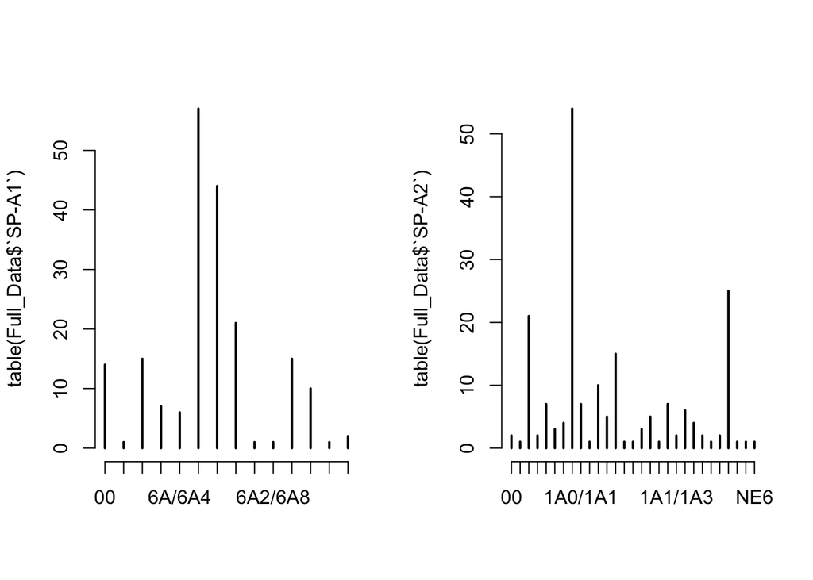

Many of the multiallelic variants have only a single to a handfull of counts. As such, in line with litterature PMID: 19914637, low count variants were combined and LR model run in following steps.

### Combining Multiallelic Variants

```r
MultiAllelic1 <- dummy_cols(Full_Data, select_columns = 'SP-A2', ignore_na=T, remove_selected_columns=T)
MultiAllelic1 <- MultiAllelic1[,-c(1:30)]

MultiAllelic2 <- dummy_cols(Full_Data, select_columns = 'SP-A1', ignore_na=T, remove_selected_columns=T)
MultiAllelic2 <- MultiAllelic2[,-c(1:30)]

MultiAllelic <- data.frame(cbind("Phenotype" = ifelse(Full_Data$Phenotype==1,0,1),
                                 MultiAllelic1,
                                 MultiAllelic2,
                                 "Age" = Full_Data$`Age In months`,
                                 "Sex" = Full_Data$Gender,
                                 "Weight" = Full_Data$Weight,
                                 "Vent_Duration" = Full_Data$`Duration of ventilation (days)`,
                                 "Infection" = Full_Data$`Bacterial Cx Pos`,
                                 "Asian" = Full_Data$Ethnicity_Asian,
                                 "Black" = Full_Data$Ethnicity_Black,
                                 "Latino" = Full_Data$Ethnicity_Latino,
                                 "Mixed" = Full_Data$Ethnicity_Mixed,
                                 "White" = Full_Data$Ethnicity_White))

MultiAllelic <- sapply(MultiAllelic, as.numeric)
MultiAllelic <- as.data.frame(MultiAllelic)

MultiAllelic$SP.A1_Other <- ifelse(Full_Data$`SP-A1` %in% c("6A2/6A3","6A2/6A2","6A/6A2","6A2/6A4","6A3/6A3"), 0, 1)

MultiAllelic$SP.A2_Other <- ifelse(Full_Data$`SP-A2` %in% c("1A0/1A0","1A/1A0","NE1","1A0/1A2","1A0/1A5"), 0, 1)

MultiAllelic <- data.frame(cbind("Phenotype"=MultiAllelic$Phenotype,
                      "Asian"=MultiAllelic$Asian,
                      "Black"=MultiAllelic$Black,
                      "Latino"=MultiAllelic$Latino,
                      "Mixed"=MultiAllelic$Mixed,
                      "Sex"=MultiAllelic$Sex,
                      "Age"=MultiAllelic$Age,
                      "Weight"=MultiAllelic$Weight,
                      "Vent_Duration"=MultiAllelic$Vent_Duration,
                      "Infection"=MultiAllelic$Infection,
                      "A21A1A0"=MultiAllelic$SP.A2_1A.1A0,
                      "A21A01A0"=MultiAllelic$SP.A2_1A0.1A0,
                      "A21A01A1"=MultiAllelic$SP.A2_NE1,
                      "A21A01A2"=MultiAllelic$SP.A2_1A0.1A2,
                      "A21A01A3"=MultiAllelic$SP.A2_1A0.1A5,
                      "A16A26A3"=MultiAllelic$SP.A1_6A2.6A3,
                      "A16A26A2"=MultiAllelic$SP.A1_6A2.6A2,
                      "A16A6A2"=MultiAllelic$SP.A1_6A.6A2,
                      "A16A26A4"=MultiAllelic$SP.A1_6A2.6A4,
                      "A16A36A3"=MultiAllelic$SP.A1_6A3.6A3))

MultiAllelic <- sapply(MultiAllelic, as.numeric)
MultiAllelic <- as.data.frame(MultiAllelic)
MultiAllelic <- na.omit(MultiAllelic)
```

### Multiallelic Model

```r
cmod1 <- glm(Phenotype ~., data=MultiAllelic, family=binomial)
summary(cmod1)
```

```
##
## Call:
## glm(formula = Phenotype ~ ., family = binomial, data = MultiAllelic)
##
## Deviance Residuals:
##     Min       1Q   Median       3Q      Max
## -1.6817  -0.8215  -0.5754   0.9891   2.6290
##
## Coefficients:
##                Estimate Std. Error z value Pr(>|z|)
## (Intercept)    -3.07147    0.97293  -3.157  0.00159 **
## Asian         -16.94532  968.61202  -0.017  0.98604
## Black           0.54674    0.49552   1.103  0.26987
## Latino          0.58756    0.46756   1.257  0.20888
## Mixed           0.10345    0.92793   0.111  0.91123
## Sex            -0.22707    0.39183  -0.580  0.56224
## Age             0.04845    0.08304   0.583  0.55958
## Weight          0.12374    0.14633   0.846  0.39776
## Vent_Duration   0.07465    0.03601   2.073  0.03816 *
## Infection       0.79586    0.42847   1.857  0.06325 .
## A21A1A0         2.72648    1.25045   2.180  0.02923 *
## A21A01A0        0.05890    0.71392   0.082  0.93425
## A21A01A1        0.36316    0.62305   0.583  0.55998
## A21A01A2        0.66866    0.87702   0.762  0.44581
## A21A01A3        0.85958    0.87178   0.986  0.32413
## A16A26A3        0.74536    0.60028   1.242  0.21435
## A16A26A2        0.19451    0.77242   0.252  0.80118
## A16A6A2        -2.90921    1.36780  -2.127  0.03343 *
## A16A26A4       -0.24065    0.81877  -0.294  0.76882
## A16A36A3        1.00203    0.71682   1.398  0.16215
## ---
## Signif. codes:  0 '***' 0.001 '**' 0.01 '*' 0.05 '.' 0.1 ' ' 1
##
## (Dispersion parameter for binomial family taken to be 1)
##
##     Null deviance: 249.60  on 194  degrees of freedom
## Residual deviance: 208.41  on 175  degrees of freedom
## AIC: 248.41
##
## Number of Fisher Scoring iterations: 15
```

For our multiallelic model we do not see any significance in any of the multiallelic variants or additional covariates following Bonferroni correction.

### Multiallelic Likelihood Ratio Tests

Finally we assess the goodness of fit between a model with clinical covariates only and a model containing clinical covariates and our genetic variants

```r
fullmodel <- glm(Phenotype ~ ., data=MultiAllelic, family=binomial)
covmodel <- glm(Phenotype ~ Sex + Age + Weight + Black + Asian + Latino + Mixed + Infection + Vent_Duration, data=MultiAllelic, family=binomial)

lrtest(fullmodel, covmodel)
```

```
## Likelihood ratio test for MLE method
## Chi-squared 10 d.f. =  11.65415 , P value =  0.3088696
```

Again, we ask does the data fit each of the two models equally well, and from this we see that with a Chisq of 11.654 and P-Value of 0.3089, that we accept the null hypothesis that the two are equal. Therefore, the model with the additional genetic variants is not a better fit and offers no significant improvement over the model with only the covarites as our predictors.